# R Notebook

```r
library(tidyverse)
library(dplyr)
library(dcData)
library(mosaic)
```

```r
download.file(url="https://mdbeckman.github.io/dcSupplement/data/CMS_ProvidersSimple.rds",
              destfile = "CMS_providers.rds")
DataTable <- readRDS("CMS_providers.rds")
```

```r
Addresses <- read_csv("https://mdbeckman.github.io/dcSupplement/data/street-addresses.csv")
Sample <-
  Addresses %>%
  sample_n(size = 50)
```

```r
View(Addresses)
```

```r
View(DataTable)
```

#Combining data tables

```r
combined_addresses <-
  DataTable%>%
  inner_join(Addresses)
count(combined_addresses)
```

| n |
| --- |
| 131 |

#Solved Example

```r
Sample <-
  Addresses %>%
  sample_n(size = 50)
head(Sample)
```

| address |
| --- |
| 367 HUNTERS FORK RD |
| PO BOX 1971 |
| 2301 VANDERBILT PL |
| PO BOX 1642 |
| NCSU BOX 15254 |
| 608 PETER CT APT D |

#3.)

```r
Matches <-
  Sample %>%
  filter(grepl(pattern = "PO", address))
head(Matches)
```

| address |
| --- |
| PO BOX 1971 |
| PO BOX 1642 |
| PO BOX 326 |
| PO BOX 1011 |
| PO BOX 1054 |
| PO BOX 6661 |

#4

```r
Dont <-
  Sample %>%
  filter( !grepl(pattern = "PO", address))
Dont
```

| address |
| --- |
| 367 HUNTERS FORK RD |
| 2301 VANDERBILT PL |
| NCSU BOX 15254 |
| 608 PETER CT APT D |
| P O BOX 393 |
| NCSU BOX 22337 |
| P O BOX 1170 |
| 1348 BOZEMAN LOOP |
| BOX 7315 |
| NCSU BOX 15580 |

[output cut: 14 more lines]

#Matches that should have been there

```r
View(Matches)
```

#Matches that should not have been there

```r
View(Dont)
```

#5.) A value that did not get caught through the filter is “P O BOX 774”

#6.)

```r
pattern <- "BOX\\s+(\\d+)"

Matches <-
  Sample %>%
  filter(grepl(pattern, address))

Dont <-
  Sample %>%
  filter( !grepl(pattern, address))
Dont
```

| address |
| --- |
| 367 HUNTERS FORK RD |
| 2301 VANDERBILT PL |
| 608 PETER CT APT D |
| 1348 BOZEMAN LOOP |
| 3405 SHADY CREEK DR |
| 1742 QUAIL RIDGE RD |
| 715 NAZARETH ST |
| 120-118 PENMARC DR |
| 1233 HERITAGE HEIGHTS |
| 1678 LOWER MONCURE RD |

```r
BoxNumbers <-
  Sample %>%
  filter(grepl(pattern, address)) %>%
  tidyr::extract(address, into = "boxnum", regex = pattern)
BoxNumbers
```

| boxnum |
| --- |
| 1971 |
| 1642 |
| 15254 |
| 326 |
| 1011 |
| 393 |
| 22337 |
| 1054 |
| 6661 |
| 1170 |

[output cut: 30 more lines]

#Your Turn

```r
pattern <- "(ST|RD|ROAD)"
LeftOvers <-
  Addresses %>%
  filter( !grepl(pattern, address),
          !grepl("\\sAPT|UNIT\\s[\\d]+$", address),
          !grepl(" BOX ", address))
head(LeftOvers)
```

| address |
| --- |
| 2117 MARINER CIRCLE |
| 101 EPPING WAY |
| 04-I ROBIN CIRCLE |
| NCSU B0X 15637 |
| 4719 BROWN TRAIL |
| 130 THE WINERY |

-In the first line, the variable pattern is being assigned to (ST|RD|ROAD) which is being used for later use in the next chunk

-In the next two lines, Addresses of registered voters are being referenced to pull the data out of it assigned to the variable LeftOvers

-In line 4, the filter statement filters out any address that have ST, RD, or Road in it.

-In line 6, all of the addresses that have BOX in it got filtered out

#Your Turn #2

```r
pattern2 <- "(CIRCLE|WAY|LN|PATH|WAY|POINT)"
LeftOvers2 <-
  Addresses %>%
  filter( !grepl(pattern2, address),
          !grepl("\\sAPT|UNIT\\s[\\d]+$", address),
          !grepl(" BOX ", address)
          )
head(LeftOvers2)
```

| address |
| --- |
| 5102 ECHO RIDGE RD |
| 5007 PURITAN RD |
| 4800 WESTERN BLVD |
| NCSU B0X 15637 |
| 2801 NELLOWOOD ST |
| 237 LARCHMONT ROAD |

```r
pattern3 <- "(CT|BLVD|COURT|TRAIL|AVENUE|STREET)"
LeftOvers3 <-
  Addresses %>%
  filter( !grepl(pattern2, address),
          !grepl("\\sAPT|UNIT\\s[\\d]+$", address),
          !grepl(" BOX ", address))
head(LeftOvers3)
```

| address |
| --- |
| 5102 ECHO RIDGE RD |
| 5007 PURITAN RD |
| 4800 WESTERN BLVD |
| NCSU B0X 15637 |
| 2801 NELLOWOOD ST |
| 237 LARCHMONT ROAD |

```r
library(stringr)

address_popularity <-
  combined_addresses %>%
  select(address) %>%
  mutate(identifiers = word(address,-1)) %>%
  group_by(identifiers) %>%
  summarise(count = n()) %>%
  arrange(desc(count))

head(address_popularity)
```

| identifiers | count |
| --- | --- |
| DR | 80 |
| ST | 20 |
| RD | 14 |
| 421 | 7 |
| NEUSE | 4 |
| STREET | 3 |

```r
library(esquisse)
esquisser(address_popularity)
```

```
Listening on http://127.0.0.1:3613
```

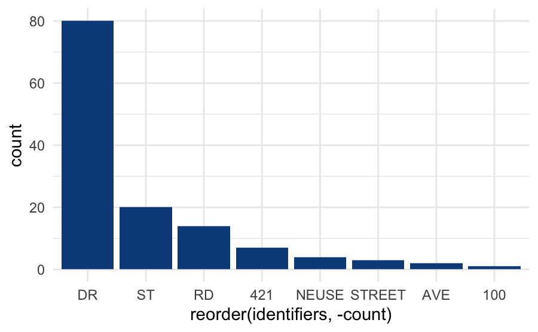

```r
ggplot(address_popularity) +
 aes(x = reorder(identifiers, -count), weight = count) +
 geom_bar(fill = "#0c4c8a") +
 theme_minimal()
```